# Assignment-1

# Question 11

```r
volt_data <- read.csv(file="VOLTAGE.csv")
head(volt_data)
```

```
##   VOLTAGE LOCATION
## 1    9.98      OLD
## 2   10.26      OLD
## 3   10.05      OLD
## 4   10.29      OLD
## 5   10.03      OLD
## 6    8.05      OLD
```

## a

```r
# Range of the VOLTAGE
range(volt_data$VOLTAGE)
```

```
## [1]  8.05 10.55
```

The following is the tabled filled out for the histogram construction:

```r
Voltdf <- read.csv(file="VOLTHIST.csv")
Voltdf
```

```
##    Class  Class.Interval Data.Tabulation Frequency Relative.Frequency
## 1      1   8.0000-8.2889               |         1         0.03333333
## 2      2   8.2889-8.5778                         0         0.00000000
## 3      3   8.5778-8.8667             |||         3         0.10000000
## 4      4   8.8667-9.1556                         0         0.00000000
## 5      5   9.1556-9.4445                         0         0.00000000
## 6      6   9.4445-9.7334             |||         3         0.10000000
## 7      7  9.7334-10.0223 ||||| ||||| |||        13         0.43333333
## 8      8 10.0223-10.3112      ||||| ||||         9         0.30000000
## 9      9 10.3112-10.6001               |         1         0.03333333
## 10 Total  8.0000-10.6001                        30         1.00000002
```

The following is the constructed relative frequency histogram for ‘old process’ voltage readings:

```r
voltage_old <- with(volt_data, volt_data[LOCATION=="OLD",])
# Histogram setup:
classrange=10.6-8.0
inc=classrange/9
bins=seq(8.0,10.6,by=inc)
#
with(voltage_old,cut(VOLTAGE,bins))
```

```
##  [1] (9.73,10]   (10,10.3]   (10,10.3]   (10,10.3]   (10,10.3]   (8,8.29]
##  [7] (10.3,10.6] (10,10.3]   (9.73,10]   (9.73,10]   (10,10.3]   (10,10.3]
## [13] (9.73,10]   (10,10.3]   (9.73,10]   (9.73,10]   (9.44,9.73] (9.73,10]
## [19] (9.44,9.73] (8.58,8.87] (9.73,10]   (10,10.3]   (9.73,10]   (9.73,10]
## [25] (9.44,9.73] (9.73,10]   (9.73,10]   (8.58,8.87] (8.58,8.87] (9.73,10]
## 9 Levels: (8,8.29] (8.29,8.58] (8.58,8.87] (8.87,9.16] ... (10.3,10.6]
```

```r
cl= with(voltage_old,cut(VOLTAGE,bins))
#
# Frequency
cl.tab=table(cl)
cl.tab
```

```
## cl
##    (8,8.29] (8.29,8.58] (8.58,8.87] (8.87,9.16] (9.16,9.44] (9.44,9.73]
##           1           0           3           0           0           3
##   (9.73,10]   (10,10.3] (10.3,10.6]
##          13           9           1
```

```r
#
voltage_old$VOLTAGE->voltage_old
length(voltage_old)
```

```
## [1] 30
```

```r
n=length(voltage_old)
#
# Relative Frequency
Rel_freq_old = cl.tab/n
Rel_freq_old
```

```
## cl
##    (8,8.29] (8.29,8.58] (8.58,8.87] (8.87,9.16] (9.16,9.44] (9.44,9.73]
##  0.03333333  0.00000000  0.10000000  0.00000000  0.00000000  0.10000000
##   (9.73,10]   (10,10.3] (10.3,10.6]
##  0.43333333  0.30000000  0.03333333
```

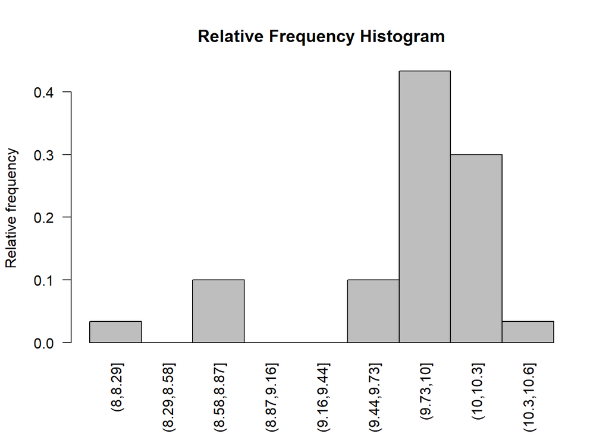

```r
#
## Main Plot
barplot(Rel_freq_old,las=2,main="Relative Frequency Histogram",ylab="Relative frequency",space=0)
```

## b

The following is the Stem & Leaf plot using **stem()** in **R**. It seems that the Histogram from part **a** can give a more visual representation of where the voltage readings lie. However, both give a fairly accurate representation of the distribution.

```r
stem(voltage_old)
```

```
##
##   The decimal point is at the |
##
##    8 | 1
##    8 | 778
##    9 |
##    9 | 677888899
##   10 | 0000000011122333
##   10 | 6
```

## c

The following is the constructed relative frequency histogram for ‘New process’ voltage readings:

```r
voltage <- with(volt_data, volt_data[LOCATION=="NEW",])
# Histogram setup:
classrange=10.6-8.0
inc=classrange/9
bins=seq(8.0,10.6,by=inc)
#
cl= with(voltage,cut(VOLTAGE,bins))
#
# Frequency
cl.tab=table(cl)
cl.tab
```

```
## cl
##    (8,8.29] (8.29,8.58] (8.58,8.87] (8.87,9.16] (9.16,9.44] (9.44,9.73]
##           0           1           6           1           7           7
##   (9.73,10]   (10,10.3] (10.3,10.6]
##           3           5           0
```

```r
#
voltage$VOLTAGE->voltage
n=length(voltage)
#
# Relative Frequency
Rel_freq = cl.tab/n
Rel_freq
```

```
## cl
##    (8,8.29] (8.29,8.58] (8.58,8.87] (8.87,9.16] (9.16,9.44] (9.44,9.73]
##  0.00000000  0.03333333  0.20000000  0.03333333  0.23333333  0.23333333
##   (9.73,10]   (10,10.3] (10.3,10.6]
##  0.10000000  0.16666667  0.00000000
```

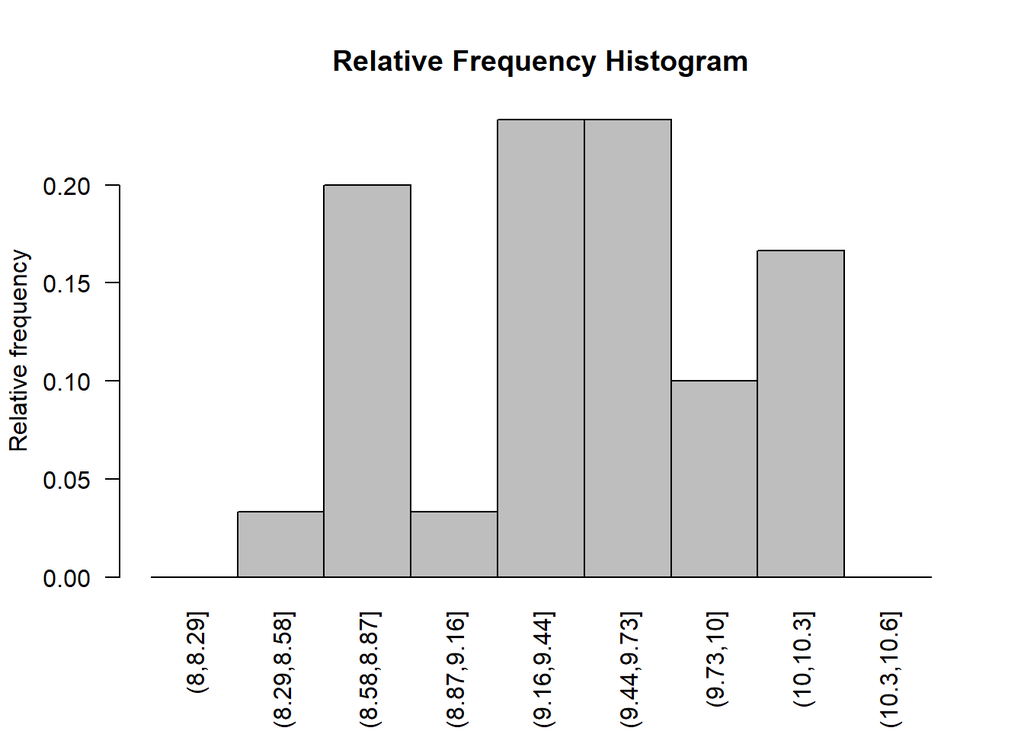

```r
#
## Main Plot
barplot(Rel_freq,las=2,main="Relative Frequency Histogram",ylab="Relative frequency",space=0)
```

## d

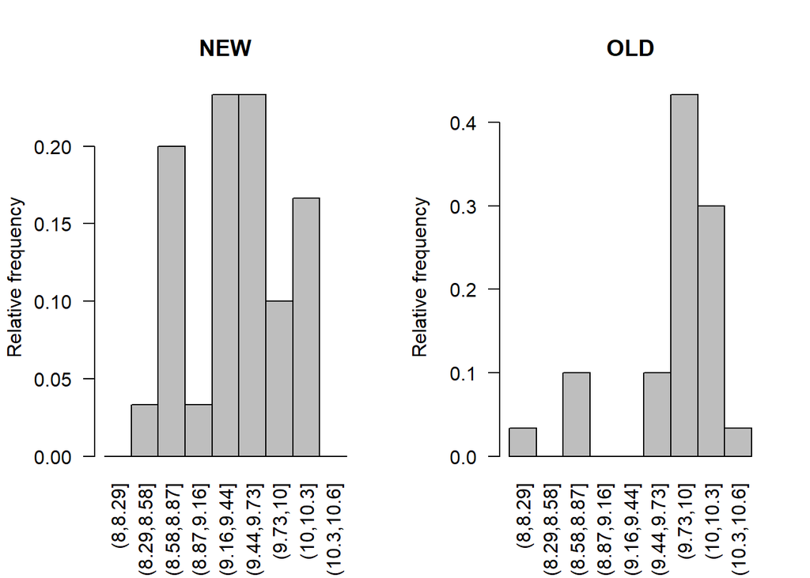

```r
layout(matrix(c(1,2),nr=1,nc=2))# 1 row 3 cols
barplot(Rel_freq,las=2,main="NEW",ylab="Relative frequency",space=0)
barplot(Rel_freq_old,las=2,main="OLD",ylab="Relative frequency",space=0)
```

## e

My preferred method for finding the central tendency would be the mean, but double checking with the median. This is because for the most part the mean can accurately depict the central tendency, but some outliers may skew this. That’s why double checking with the median is a good option.

The following is the **OLD**:

```r
mean(voltage_old)
```

```
## [1] 9.803667
```

```r
median(voltage_old)
```

```
## [1] 9.975
```

```r
find_mode(voltage_old)
```

```
## [1]  9.98 10.26 10.05  9.87  9.80 10.15  8.72  9.84
```

The following is the **NEW**

```r
mean(voltage)
```

```
## [1] 9.422333
```

```r
median(voltage)
```

```
## [1] 9.455
```

```r
find_mode(voltage)
```

```
## [1] 8.82
```

## f

The z-score of the **OLD** location is N/A.

```r
volt_10_old <- with(volt_data, volt_data[VOLTAGE>=10.5 & LOCATION=="OLD",])
head(volt_10_old)
```

```
##   VOLTAGE LOCATION
## 7   10.55      OLD
```

```r
z <- (volt_10_old$VOLTAGE-mean(volt_10_old$VOLTAGE))/sd(volt_10_old$VOLTAGE)
z
```

```
## [1] NA
```

## g

```r
volt_10_new <- with(volt_data, volt_data[VOLTAGE>=10.5 & LOCATION=="NEW",])
head(volt_10_new)
```

```
## [1] VOLTAGE  LOCATION
## <0 rows> (or 0-length row.names)
```

```r
z <- (volt_10_new$VOLTAGE-mean(volt_10_new$VOLTAGE))/sd(volt_10_new$VOLTAGE)
z
```

```
## numeric(0)
```

## h

The **OLD** location is more likley; as the **NEW** location seems to not have a reading of $10.5$ or above.

## i

Yes, there seem to be several possible outliers.

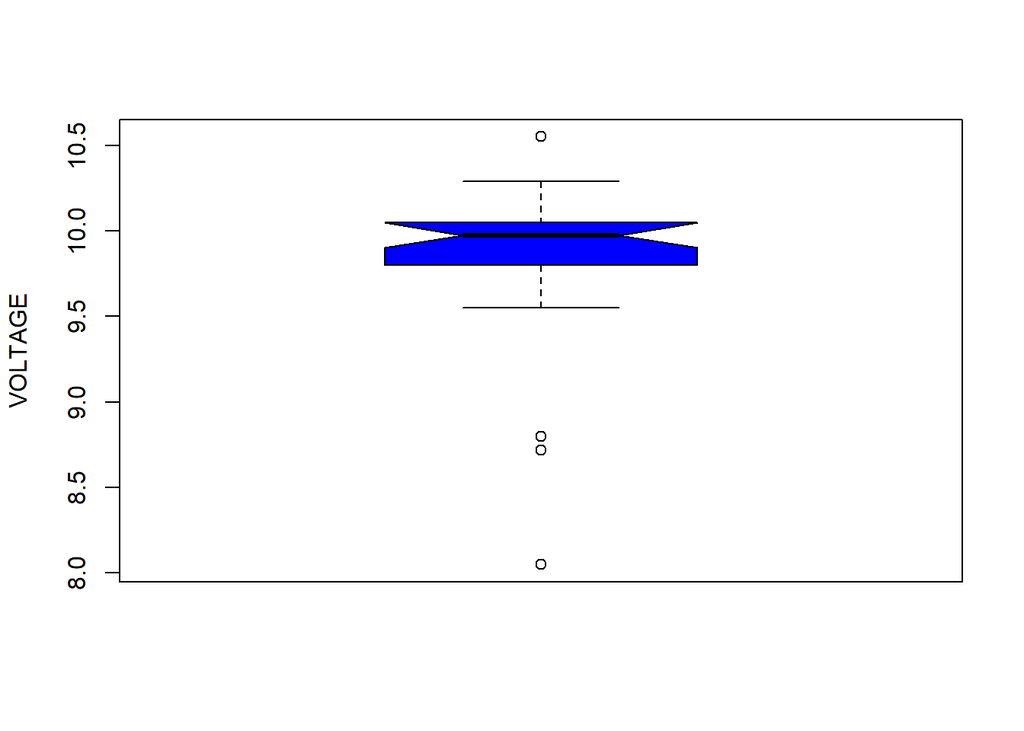

```r
boxplot(voltage_old,ylab="VOLTAGE",col="Blue",notch=TRUE)
```

## j

The z-scores detected that $8.05$ is an outlier for the **OLD** location; with $8.72$ being a possible outlier:

```r
z <- (voltage_old-mean(voltage_old))/sd(voltage_old)
z
```

```
##  [1]  0.325990556  0.843631515  0.455400796  0.899093047  0.418426442
##  [6] -3.242034625  1.379759651  0.843631515  0.307503379  0.122631608
## [11]  0.584811036  0.455400796 -0.006778632  0.640272567  0.362964911
## [16]  0.122631608 -0.468958059  0.270529025 -0.191650403 -2.003393759
## [21]  0.067170077  0.640272567  0.399939265 -0.006778632 -0.136188871
## [26]  0.381452088  0.325990556 -2.003393759 -1.855496342  0.067170077
```

```r
# Find the z values greater than 3 in size
z[abs(z)>3]
```

```
## [1] -3.242035
```

```r
# Find the I values corresponding to these z values
voltage_old[abs(z)>3]
```

```
## [1] 8.05
```

```r
# Find the values of z that are possible outliers
z[abs(z)>=2 & abs(z)<=3]
```

```
## [1] -2.003394 -2.003394
```

```r
#Find the values of I which are possible outliers
voltage_old[abs(z)>=2 & abs(z)<=3]
```

```
## [1] 8.72 8.72
```

## k

No, there seems to be no significant outlier.

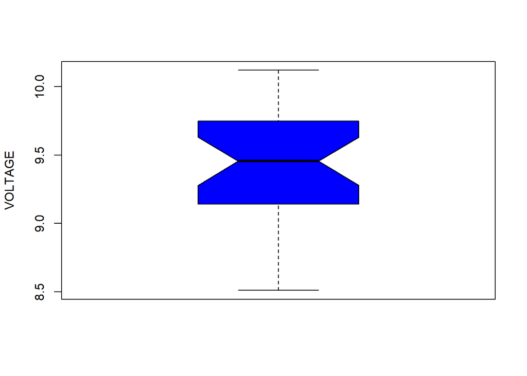

```r
boxplot(voltage,ylab="VOLTAGE",col="Blue",notch=TRUE)
```

## l

The z-scores did **NOT** detect any outliers at the **NEW** location:

```r
z <- (voltage-mean(voltage))/sd(voltage)
z
```

```
##  [1] -0.48516415  0.43365462  1.41512012  0.57983033  1.39423788  0.37100788
##  [7]  1.31070890  1.45688461  0.14130319 -0.10928375  1.22717992 -1.25780721
## [13]  0.01600972  1.26894441  0.89306400 -0.31810620 -1.23692497 -0.06751926
## [19]  0.12042095  0.45453686 -1.25780721 -1.61280538 -1.90515680 -0.58957538
## [25]  0.68424156 -1.34133619 -0.15104824  0.24571441 -0.13016599 -1.55015864
```

```r
# Find the z values greater than 3 in size
z[abs(z)>3]
```

```
## numeric(0)
```

```r
# Find the I values corresponding to these z values
voltage[abs(z)>3]
```

```
## numeric(0)
```

```r
# Find the values of z that are possible outliers
z[abs(z)>=2 & abs(z)<=3]
```

```
## numeric(0)
```

```r
#Find the values of I which are possible outliers
voltage[abs(z)>=2 & abs(z)<=3]
```

```
## numeric(0)
```

## m

As can be seen below the **NEW** location has practically no outliers as compared to the **OLD** location. However a larger portion of the **NEW** voltage readigns fall below the minimum requirment as stated in the problem statemnt. This means that the **NEW** Location is more predictable, yet not as optimal.

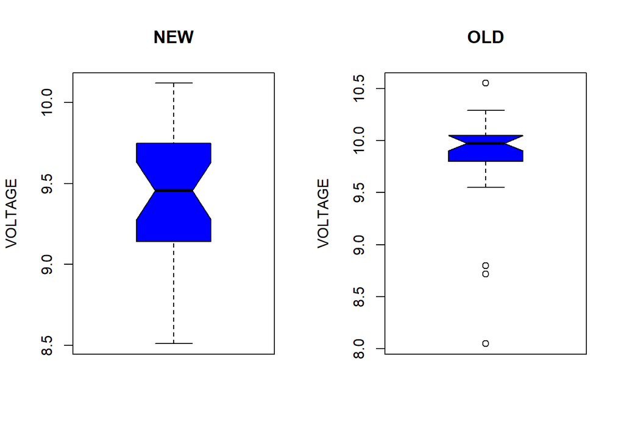

```r
layout(matrix(c(1,2),nr=1,nc=2))# 1 row 3 cols
boxplot(voltage,main="NEW",ylab="VOLTAGE",col="Blue",notch=TRUE)
boxplot(voltage_old,main="OLD",ylab="VOLTAGE",col="Blue",notch=TRUE)
```

# Question 12

The interval, calculated below, that contains $95\%$ of all the roughness measurments is: $(0.8331772,$ $2.9288228)$

```r
rough <- read.csv(file="ROUGHPIPE.csv")
head(rough)
```

```
##   ROUGH
## 1  1.72
## 2  2.57
## 3  2.50
## 4  2.64
## 5  2.16
## 6  1.26
```

```r
s_12 <- sd(rough$ROUGH)
y_bar = mean(rough$ROUGH)
interval = c(y_bar-2*s_12,y_bar+2*s_12 )
interval
```

```
## [1] 0.8331772 2.9288228
```

# Question 13

```r
gobiants <- read.csv(file = "GOBIANTS.csv")
head(gobiants)
```

```
##   Site      Region Rain Temp PlantCov AntSpecies Diversity
## 1    1  Dry Steppe  196  5.7       40          3      0.89
## 2    2  Dry Steppe  196  5.7       52          3      0.83
## 3    3  Dry Steppe  179  7.0       40         52      1.31
## 4    4  Dry Steppe  197  8.0       43          7      1.48
## 5    5  Dry Steppe  149  8.5       27          5      0.97
## 6    6 Gobi Desert  112 10.7       30         49      0.46
```

## a

The results for the mean, median, and mode are: $12.81818$, $5$, and $5$ & $4$ respectively. The mean shows the most accurate central tendency. While the median shows the middle value within the data yet not necessarily the central tendency. while the mode shows the most frequent occurring data points; which would be $5$ & $4$ equally.

```r
# Mean
mean(gobiants$AntSpecies)
```

```
## [1] 12.81818
```

```r
# Median
median(gobiants$AntSpecies)
```

```
## [1] 5
```

```r
# Mode
find_mode(gobiants$AntSpecies)
```

```
## [1] 5 4
```

## b

In this case I would use the **Median** & **Mode** for the central tendency as they are both approximately $5$. This means that outliers may have skewed the mean.

## c

The results for the mean, median, and mode are: $40.4$, $40$, and $40$ respectively.

```r
Dry_Steppe <- with(gobiants, gobiants[Region=="Dry Steppe",])
head(Dry_Steppe)
```

```
##   Site     Region Rain Temp PlantCov AntSpecies Diversity
## 1    1 Dry Steppe  196  5.7       40          3      0.89
## 2    2 Dry Steppe  196  5.7       52          3      0.83
## 3    3 Dry Steppe  179  7.0       40         52      1.31
## 4    4 Dry Steppe  197  8.0       43          7      1.48
## 5    5 Dry Steppe  149  8.5       27          5      0.97
```

```r
# Mean
mean(Dry_Steppe$PlantCov)
```

```
## [1] 40.4
```

```r
# Median
median(Dry_Steppe$PlantCov)
```

```
## [1] 40
```

```r
# Mode
find_mode(Dry_Steppe$PlantCov)
```

```
## [1] 40
```

## d

The results for the mean, median, and mode are: $28$, $26$, and $30$ respectively.

```r
Gobi_Desert <- with(gobiants, gobiants[Region=="Gobi Desert",])
head(Gobi_Desert)
```

```
##    Site      Region Rain Temp PlantCov AntSpecies Diversity
## 6     6 Gobi Desert  112 10.7       30         49      0.46
## 7     7 Gobi Desert  125 11.4       16          5      1.23
## 8     8 Gobi Desert   99 10.9       30          4        NA
## 9     9 Gobi Desert  125 11.4       56          4      0.76
## 10   10 Gobi Desert   84 11.4       22          5      1.26
## 11   11 Gobi Desert  115 11.4       14          4      0.69
```

```r
# Mean
mean(Gobi_Desert$PlantCov)
```

```
## [1] 28
```

```r
# Median
median(Gobi_Desert$PlantCov)
```

```
## [1] 26
```

```r
# Mode
find_mode(Gobi_Desert$PlantCov)
```

```
## [1] 30
```

## e

Yes the regions had a different plant coverage percentage distribution. The central tendency for the **Dry Steppe** was approximately $40$ which was confirmed by the mean median and mode. While the central tendency for the **Gobi Desert** was near $28$ given by the mean.

# Question 14

```r
galaxy <- read.csv(file = "GALAXY2.csv")
head(galaxy)
```

```
##   VELOCITY
## 1    22922
## 2    20210
## 3    21911
## 4    19225
## 5    18792
## 6    21993
```

## a

The following boxplot describes the velocity distribution of the galaxy cluster:

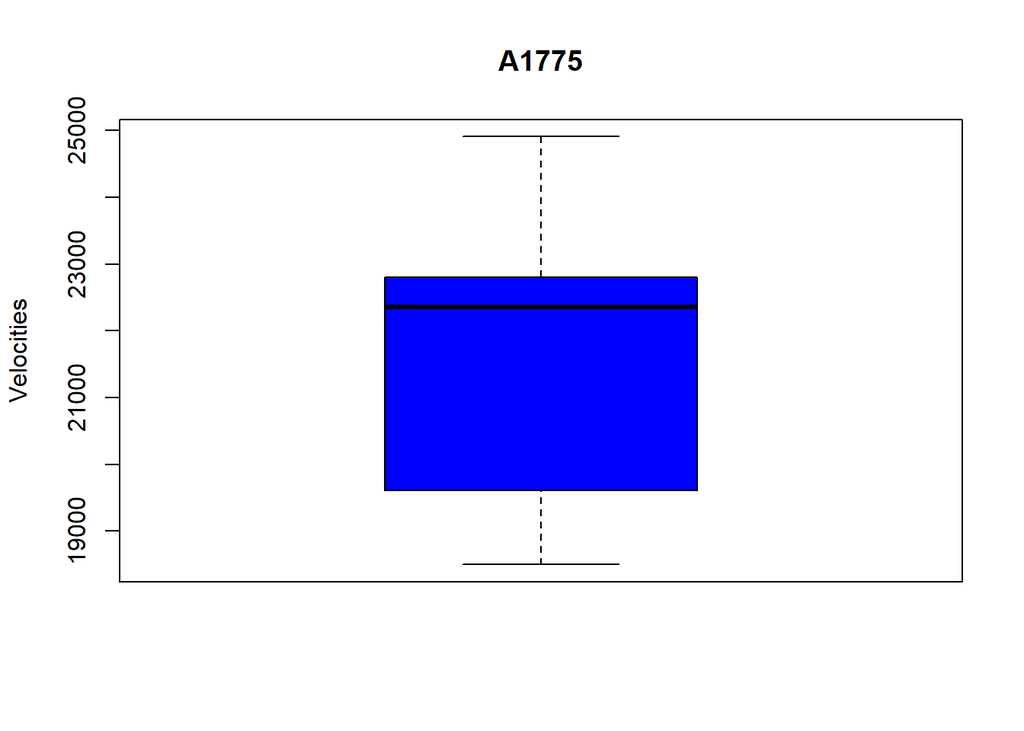

```r
boxplot(galaxy$VELOCITY,main="A1775",ylab="Velocities",col="Blue",notch=FALSE)
```

## b

Yes, as there seems to be two distinct velocities, one under $22,000$ km and one above.

## c

From the following calcuationscluster A1775A and it’s velocity will be described by the **mean**; while A1775B’s velocity is described by the **median**.

The **mean** of the velocities is:

```r
mean(galaxy$VELOCITY)
```

```
## [1] 21448.25
```

The **median** of the velocities is:

```r
median(galaxy$VELOCITY)
```

```
## [1] 22355
```

The **standard deviation** of the velocities is:

```r
sd(galaxy$VELOCITY)
```

```
## [1] 1764.103
```

## d

A velocity of $20,000$ km/s would be the cluster A1775A, as it is closer to the **mean** of $21,448.25$ km/s which describes cluster A1775A as compared to the **median** of $22,355$ km/s that describes the cluster A1775B.

# Question 15

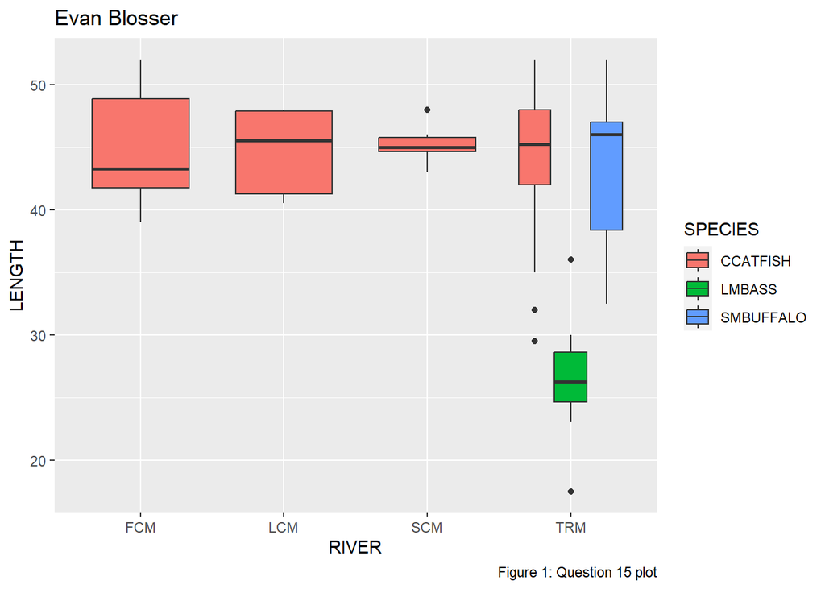

```r
Plot_15 <- ggplot(ddt, aes(x=RIVER, y=LENGTH, fill=SPECIES)) + geom_boxplot() + ggtitle("Evan Blosser")
Plot_15 + labs(caption = "Figure 1: Question 15 plot")
```